# Factors associated with coverage of deworming in Kenya.

CEMA

2023-08-01

# 1 Introduction

We have been given a dataset which contains monthly data for children <5 years, disaggregated at a county level for the period January 2021 to June 2023.

The dataset contains the following variables:

- Period (months from January 2021 to June 2023)
- County (the 47 counties in Kenya)
- Total number of children dewormed (Total Dewormed)
- Number of children <5 years with acute malnutrition (Acute Malnutrition)
- Number of children stunted (0-6 months, 6-23 months, 24-59 months)
- Number of children <5 years with diarrhea (Diarrhea cases)
- Number of children who are underweight (0-6 months, 6-23 months, 24-59 months)

We would like to first explore the data before we formulate a research question.

# 2 Data Loading and Exploration

The data was obtained from the link. The data initially contained 1,410 observations (rows) and 11 variables (columns).

[output not shown]

The columns contain county level data on some health indicators for children below 5 years. Specifically,these are: - Number of children dewormed - Number of children with acute malnutrition - Number of children stunted - Number of children underweight

The first thing we need to do is combine the data on stunting and underweight into one column for children <5 years, and change the period column to a date:

## 2.1 Missing Values

Table 2.1: Number of missing values in each column

| Column | Missing values |
| --- | --- |
| acute_malnutrition | 355 |

According to the table, only the variable “acute malnutrition” had 355 missing values. Further investigation revealed that certain counties had no records of Acute Malnutrition across the 30-month period (spanning from January 2021 to June 2023). Specifically, Elgeyo Marakwet, Kericho, and Lamu counties each had 30 missing values in the “Acute Malnutrition” variable, indicating a lack of data on Acute Malnutrition for these counties (Table 2.2). Thus, imputing the missing values with measures like mean, median, or mode for this counties deemed impractical.

Table 2.2: Counties with the leading missing values in Acute Malnutrition

| county | Missing_Values |
| --- | --- |
| Elgeyo Marakwet | 30 |
| Kericho | 30 |
| Lamu | 30 |
| Uasin Gishu | 28 |
| Nyandarua | 27 |
| Bomet | 24 |
| Kisii | 24 |
| Nyamira | 23 |
| Kirinyaga | 20 |
| Taita Taveta | 20 |
| Siaya | 19 |
| Bungoma | 17 |
| Busia | 15 |
| Nandi | 14 |

The presence of missing values in the dataset could carry various implications depending on the specific county. For instance, in certain counties, these missing values might indicate that no observation was recorded or that the actual count was zero. As stated earlier, some counties exhibited missing values across all months, suggesting a complete absence of data for those particular counties. We then decided to drop the column “acute malnutrition”.

## 2.2 Descriptive Statistics

Table 2.3 represents the descriptive statistics of the first four continuous variables in the data. We can see that among the three health syndromes or conditions, diarrhea has the highest number of cases (>2500) per year. Of the three years, 2023 had the highest number of health syndromes or conditions reported, and equally the highest number of children <5 years who were dewormed.

Table 2.3: Annual average number of cases reported and treatment administered among children <5 years in Kenya between 2021 to 2023

| Year | Dewormed | Diarrhea | Stunted | Underweight |
| --- | --- | --- | --- | --- |
| 2021 | 10139 | 2596 | 419 | 926 |
| 2022 | 12180 | 2765 | 532 | 1205 |
| 2023 | 12652 | 3344 | 726 | 1644 |

# 3 Data Visualization

We now visualise the trend in the average number of cases reported every month from January 2021 to June 2023, and the treatment data (deworming). The deworming data, (brown points), is interpreted using the secondary y axis on the right. We observe an overall increasing trend in the reported cases of diarrhea, stunting and underweight, and also in the number of children dewormed.

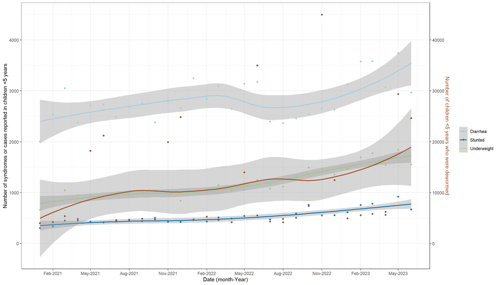

## 3.1 Choropleth map

This section showcases the prevalence of various malnutrition conditions in Kenya through an interactive choropleth map. The map allows users to hover over each county to access detailed information on specific health indicators. For an optimal viewing experience, it is recommended to knit the document in HTML format.

When we plot the data, we are not able to see the county differences due to the unfavourable scale we have due to the high number of children dewormed. To unmask the differences, we use breaks to categorise the data.

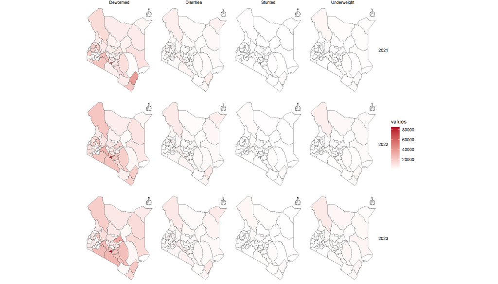

There are many methods of choosing breaks, but for this data, we will use quantiles.

```
## style: quantile
##      [21,432.4)  [432.4,1015.2) [1015.2,2254.6) [2254.6,5877.8)  [5877.8,85249]
##             113             113             112             113             113
```

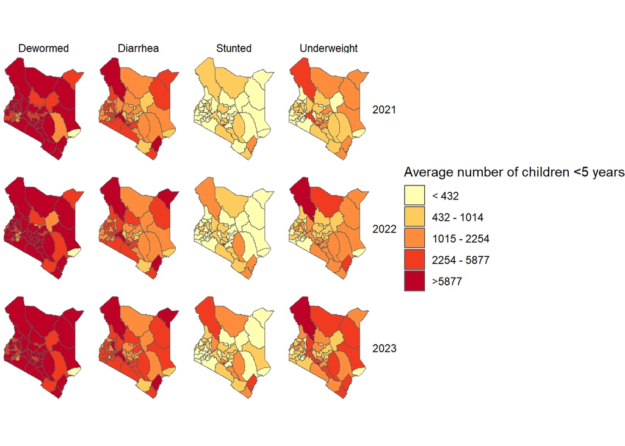

We observe that: - There has been a relatively high number of children dewormed in the country, except in the Coastal and Western region. - A high number of stunting and underweight cases is observed in the arid and semi-arid areas.

To further explore these differences, we would then calculate the number of cases observed per 100,000 children to help us have a standard way of comparing the counties. This is mainly calculated using the population data together with the number of observed cases.

## 3.2 Research question

From our exploratory data analysis, we have observed cases of diarrhea, stunting and underweight, and relatively high number of children dewormed in the different counties and years. We would then want to assess: - **what are the factors associated with coverage of deworming in Kenya?** Here, we will use a mixed effects model to answer the question.

But first, we need to include the population data to be able to calculate the coverage of deworming in every county, and the incidence of cases per 100,000 children <5 years.

Start with visualizing our data- we observe similar trends

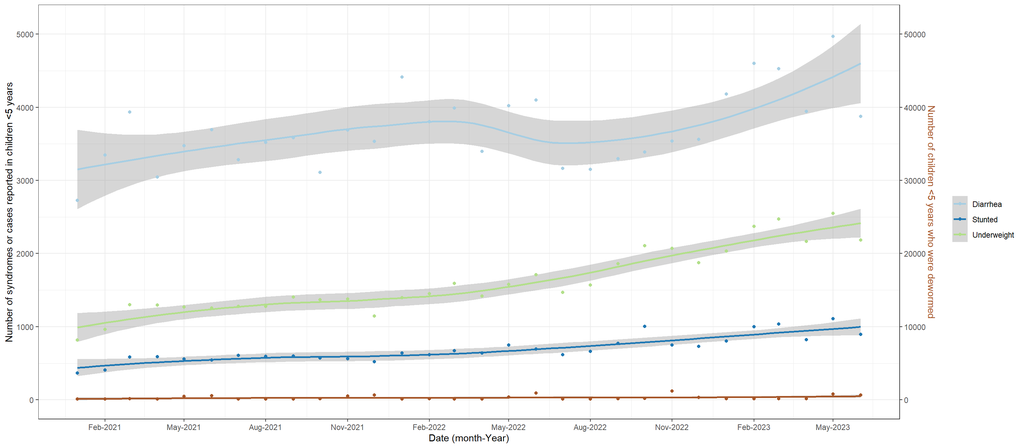

```
## style: quantile
##   [6,257.2) [257.2,593)  [593,1453) [1453,2754) [2754,9426]
##         113         112         113         113         113
```

[figure not shown]

We now go ahead to the statistical model. Our outcome variable is coverage of deworming. We will need to check if the data is skewed. There are many ways to do this- in our case we will use a histogram

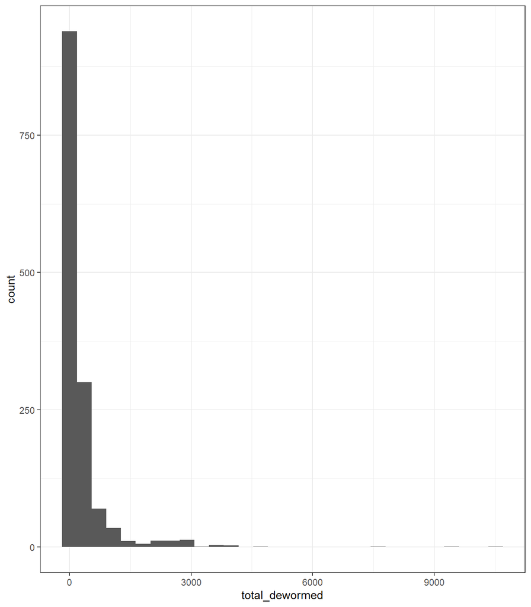

We observe that our data is skewed. We will then use a negative binomial model.

We first conduct univariable model analysis.

```
##                           2.5 %  97.5 %
## (Intercept)     1.32587 1.19576 1.47013
## diarrhoea_cases 0.99997 0.99995 0.99999
```

```
## --------------------------------------------
## Maximum Likelihood estimation
## Newton-Raphson maximisation, 6 iterations
## Return code 8: successive function values within relative tolerance limit (reltol)
## Log-Likelihood: -8752.749
## 2  free parameters
## Estimates:
##                   Estimate Std. error t value  Pr(> t)
## (Intercept)      2.821e-01  5.270e-02   5.353 8.66e-08 ***
## diarrhoea_cases -3.185e-05  1.083e-05  -2.942  0.00326 **
## ---
## Signif. codes:  0 '***' 0.001 '**' 0.01 '*' 0.05 '.' 0.1 ' ' 1
## --------------------------------------------
```

```
##                       2.5 %  97.5 %
## (Intercept) 1.05497 0.97648 1.13978
## stunted     1.00018 1.00013 1.00024
```

```
## --------------------------------------------
## Maximum Likelihood estimation
## Newton-Raphson maximisation, 6 iterations
## Return code 8: successive function values within relative tolerance limit (reltol)
## Log-Likelihood: -8739.834
## 2  free parameters
## Estimates:
##              Estimate Std. error t value  Pr(> t)
## (Intercept) 5.352e-02  3.945e-02   1.357    0.175
## stunted     1.837e-04  2.883e-05   6.373 1.86e-10 ***
## ---
## Signif. codes:  0 '***' 0.001 '**' 0.01 '*' 0.05 '.' 0.1 ' ' 1
## --------------------------------------------
```

```
##                       2.5 %  97.5 %
## (Intercept) 1.06723 0.98551 1.15573
## underweight 1.00007 1.00004 1.00009
```

```
## --------------------------------------------
## Maximum Likelihood estimation
## Newton-Raphson maximisation, 6 iterations
## Return code 8: successive function values within relative tolerance limit (reltol)
## Log-Likelihood: -8747.016
## 2  free parameters
## Estimates:
##              Estimate Std. error t value  Pr(> t)
## (Intercept) 6.507e-02  4.065e-02   1.601    0.109
## underweight 6.574e-05  1.368e-05   4.806 1.54e-06 ***
## ---
## Signif. codes:  0 '***' 0.001 '**' 0.01 '*' 0.05 '.' 0.1 ' ' 1
## --------------------------------------------
```

[figure not shown]

From these analysis, we may observe that the coverage of deworming was significantly associated (though weakly) with: - An increased risk in stunted cases per 100,000 - A decreased risk in diarrhea cases per 100,000

The result of an increased risk in stunting may be explained by the fact that these children may already be stunted by the time they are enrolled into the deworming program (as deworming starts from 2 years) and the effect of the intervention may not be seen in a short term period.